# Factor Justification

# Dementia

## Correlation Matrices

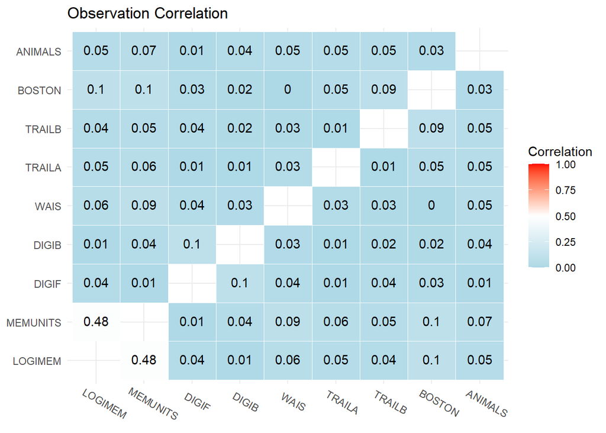

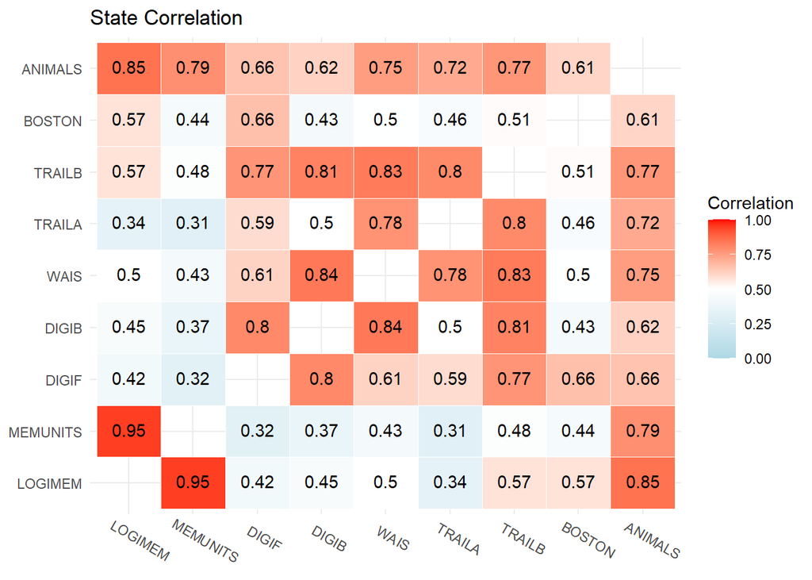

## State Cor PCs

First, I take the eigenvalue decomposition from the correlation matrix.

### How many factors should I choose?

To decide the number of factors, I take into account how many of the principle components it takes to reach 95% of the variance of the outcomes, which happens at about 4 factors.

| pc | prop | cumprop |
| --- | --- | --- |
| PC_1 | 0.656 | 0.656 |
| PC_2 | 0.153 | 0.809 |
| PC_3 | 0.077 | 0.885 |
| PC_4 | 0.063 | 0.948 |
| PC_5 | 0.031 | 0.979 |
| PC_6 | 0.014 | 0.993 |
| PC_7 | 0.007 | 1.000 |
| PC_8 | 0.000 | 1.000 |
| PC_9 | 0.000 | 1.000 |

## Factor Loadings

To get the factor loadings I use eigen vectors * sqrt(eigen values).

|  | PC_1 | PC_2 | PC_3 | PC_4 |
| --- | --- | --- | --- | --- |
| LOGIMEM | -0.196 | 0.924 | 0.251 | 0.108 |
| MEMUNITS | -0.132 | 0.968 | 0.105 | 0.123 |
| DIGIF | -0.456 | 0.148 | 0.373 | 0.287 |
| DIGIB | -0.880 | 0.206 | 0.125 | 0.179 |
| TRAILA | -0.251 | 0.142 | 0.170 | 0.927 |
| TRAILB | -0.560 | 0.321 | 0.151 | 0.567 |
| WAIS | -0.756 | 0.255 | 0.205 | 0.560 |
| BOSTON | -0.169 | 0.297 | 0.895 | 0.198 |
| ANIMALS | -0.306 | 0.695 | 0.222 | 0.503 |

I then do abs(loading)/sum(loading) for each column to see the relative loading of each test. This gets at which tests are most highly loaded onto the factor.

|  | PC_1 | PC_2 | PC_3 | PC_4 |
| --- | --- | --- | --- | --- |
| LOGIMEM | 0.053 | 0.234 | 0.101 | 0.031 |
| MEMUNITS | 0.036 | 0.245 | 0.042 | 0.036 |
| DIGIF | 0.123 | 0.037 | 0.149 | 0.083 |
| DIGIB | 0.237 | 0.052 | 0.050 | 0.052 |
| TRAILA | 0.068 | 0.036 | 0.068 | 0.269 |
| TRAILB | 0.151 | 0.081 | 0.060 | 0.164 |
| WAIS | 0.204 | 0.064 | 0.082 | 0.162 |
| BOSTON | 0.046 | 0.075 | 0.358 | 0.057 |
| ANIMALS | 0.083 | 0.176 | 0.089 | 0.146 |

## Factor loading plots

### PC_1

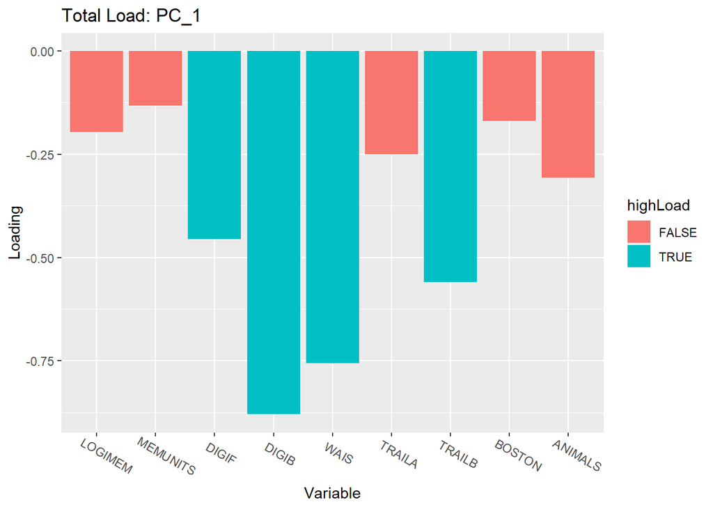

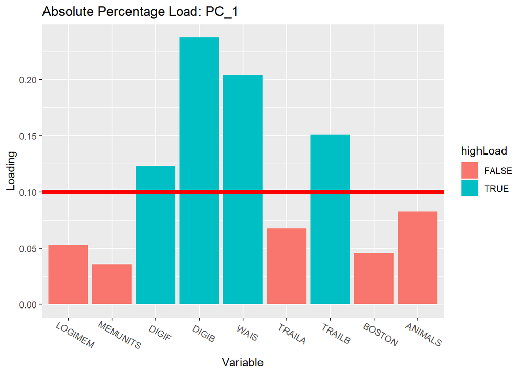

### PC_2

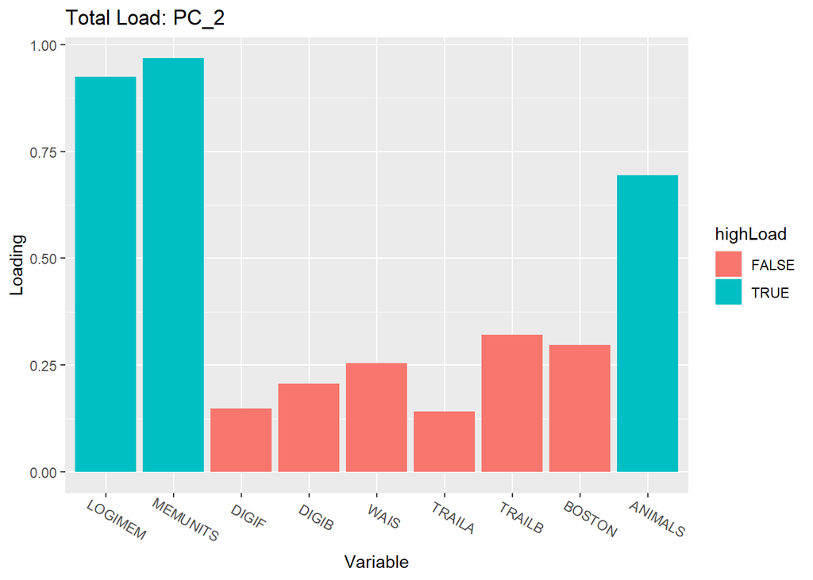

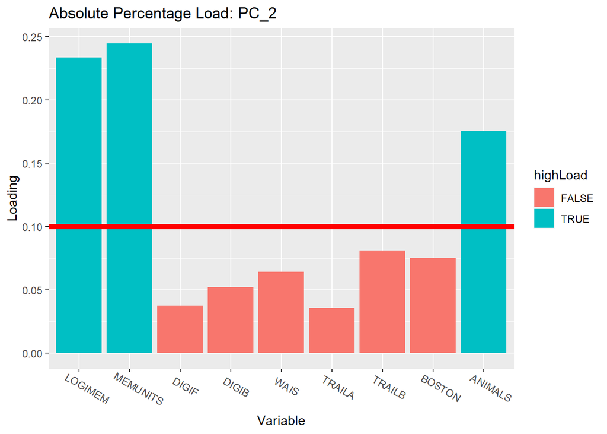

### PC_3

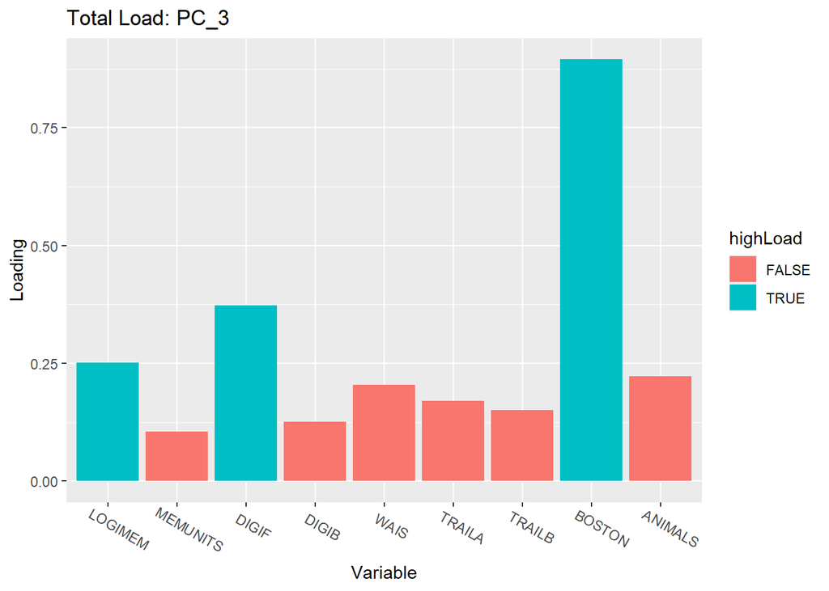

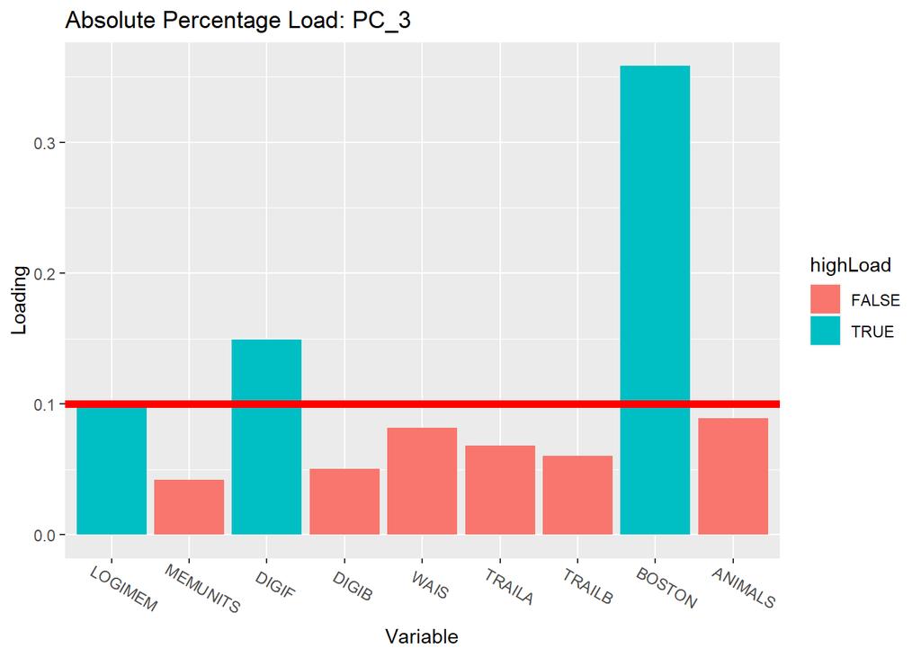